# STAT340 Discussion 2: Conditional Probability

## XKCD comic

[figure not shown]

In this lab we’ll explore some fun and weird paradoxes and fallacies related to conditional probability.

## Berkson’s Paradox

Are attractive people more likely to be jerks? This is an observation some people make - it seems when going on a date with someone the more attractive they are the worse their personality seems to be. Why could this possibly be?

This can be explained using conditional probability. Suppose that in the population people’s personalities are uniformly distributed between 1 and 10, same goes for attractiveness.

```r
#Build the population
set.seed(1)
pop.size <- 100000

#The ceiling function rounds up. Taking a uniform from 0 to 10 and rounding up will give us an integer from 1 to 10
attractiveness <- ceiling(runif(pop.size,0,10))
personality <- ceiling(runif(pop.size,0,10))
dating.population <- data.frame(attractiveness,personality)
```

What is the correlation between attractiveness and personality in the population? You can use the cor function in R to calculate correlation.

```r
  # TODO: code goes here.
cor(dating.population$attractiveness, dating.population$personality)
```

```
## [1] -0.005151473
```

*The correlation is close to zero. The two variables are independently defined so it makes perfect sense that they would have a correlation of zero.*

Let’s imagine a new dating app called “Date’em”. The population using the app is representative of the overall population. When you view someone’s profile you make some judgement about their personality as well as their attractiveness. Suppose you will only swipe right if the sum of their attractiveness and personality is at least 10.

Go through the population and create a subset who get a right swipe. You can use the subset(df, condition) function to do this easily in R. After you do, check the correlation between attractiveness and personality.

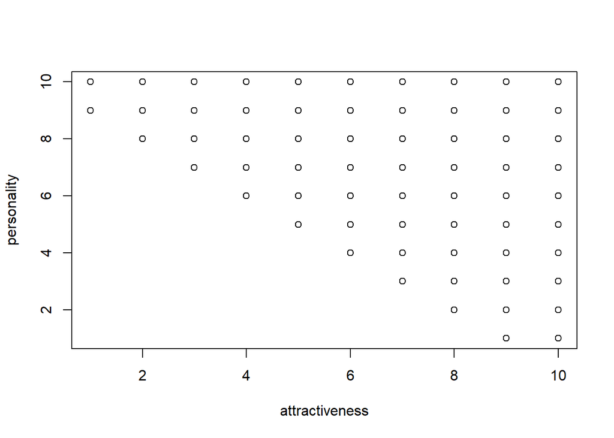

```r
swipe.right = subset(dating.population, (dating.population$attractiveness+dating.population$personality)/2 >= 5)
plot(swipe.right)
```

```r
cor(swipe.right$personality, swipe.right$attractiveness)
```

```
## [1] -0.4639471
```

*The correlation is -.4639. We have a negative correlation, so in this subset of the population we have a negative association : those with higher attractiveness are generally don’t have as good personalities.*

Consider other standards (higher and lower) for the sum of these two traits. What is the correlation in the subset for others. Bonus: You could create a vector standard <- 2:19 and for each standard calculate the correlation, then plot the two variables to see the effect of someone’s “Swipe Right” standard on the people they potentially get matched with.

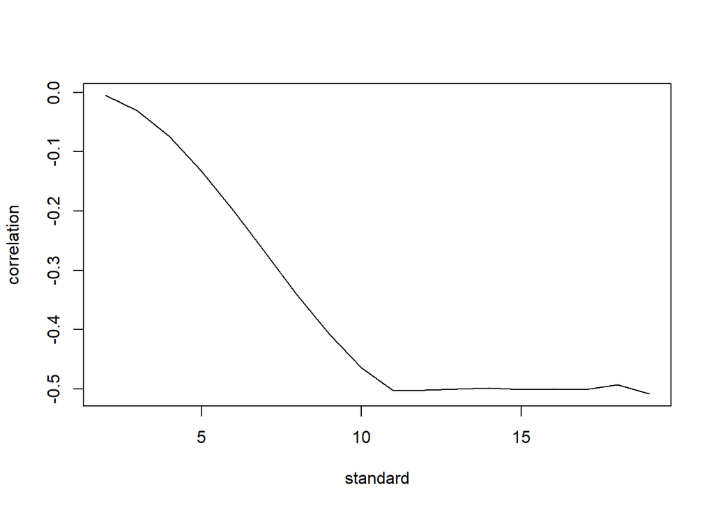

```r
standard <- 2:19
correlation <- rep(0, length(standard))
for(std in standard){
  swipe.right = subset(dating.population, (dating.population$attractiveness+dating.population$personality) >= std)
  correlation[std-1] <- cor(swipe.right$personality, swipe.right$attractiveness)
}
plot(standard,correlation, type="l")
```

Big question: If it seems that when dating that attractive people tend to be jerks, is there another explanation for this?

*It seems that the higher standards someone has in terms of who they date, the more noticeable the effect of a negative correlation will emerge. It seems to max out at a standard of 11, which makes sense geometrically. That’s the point at which we get a triangular subset of the population, and the shape remains triangular as the standard increases and increases.*

### The Book Award

Researchers have found that quality ratings for books that had won literary awards went down after the book won the award. This seems paradoxical, since people usually like books more if they know other people like them.

Imagine an author who has a cult following. Fans of this author love their books in general. A new book is published and the ratings received from fans can be modeled with a binomial(5,.9) random variable. When someone from the general public reads the book they give it a rating from a binomial(5,.5) distribution.

Suppose that for the first 5 months that 90% of the ratings come from fans of the author and only 10% come from people in the general public. What would the average star rating on Amazon be?

```r
.90 * (5*.9) + .10*(5*.5)
```

```
## [1] 4.3
```

*Under this scenario the average star rating would be 4.3, primarily because the majority of those reading the book are fans of the author.*

Then the book receives an award. This is big news and the readership changes as a lot of people buy the book because it is popular. Now 80% of the people who read the book are coming from the general public and only 20% are from the fanbase. What would the average star rating be now?

```r
.20 * (5*.9) + .80*(5*.5)
```

```
## [1] 2.9
```

*Perhaps surprisingly the star rating drops down to 2.9 stars. This makes sense when you realize that now the general public is the vast majority of readers and they aren’t as biased as fans of the author are. There’s no accounting for taste.*

### Mediocre State University

Not everybody gets into the best college. That’s just the way it is. For those who can’t get into the best university there’s Mediocre State University (MSU). Their motto: “You take the best, we’ll take the rest.”

AS the first years are getting to know each other they discover a weird trend; those who got high GPAs in high school tended to have low SAT scores, and vice versa. How could this be the case?

Let’s simplify the college application process and imagine that schools just look at two factors: a student’s GPA and a student’s SAT score.

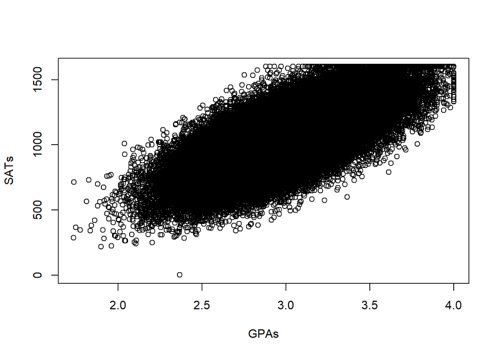

```r
# Build a population of high school seniors applying for college.
pop.size <- 100000
GPAs <- rnorm(pop.size, 3,.3)
GPAs <- pmin(GPAs, 4)
GPAS <- pmax(GPAs,0)
SATs <- 1050+500*(GPAs-3)+rnorm(pop.size,0,150)
SATs <- pmin(SATs,1600)
SATs <- pmax(SATs,0)
seniors <- data.frame(GPAs, SATs)
plot(GPAs,SATs)
```

What is the correlation between GPA and SAT score in the population of high school seniors?

```r
#To Do: Code goes here

cor(GPAs, SATs)
```

```
## [1] 0.7083942
```

*In the population of graduating seniors the correlation between GPA and SAT score is .708. This is a strong positive correlation. Those with higher GPAs tend to have higher SAT scores. That makes perfect sense.*

Do you remember what a z-score is? Given a set of data, the z-score of a value is a standardized value. Standardization is done by subtracting the sample mean and dividing by the sample standard deviation. Don’t forget parentheses around the numerator.

$$z = \frac{x-\bar{x}}{s}$$

```r
#Create a vector called zGPAs where you standardize the GPA scores into z-scores
zGPAs <- (GPAs - mean(GPAs))/sd(GPAs)

#Create another vector called zSATs where you standardize the SAT scores into z-scores
zSATs <- (SATs - mean(SATs))/sd(SATs)
```

Mediocre State University does not have the highest standards for acceptance. As long as the average z-score for GPA and SAT are above 0 a person is accepted.

However there’s another school that students really want to go into: Exceptional State University. Their acceptance standards are higher. A the average of an applicant’s GPA and SAT z score needs to be at least 1 to be accepted to ESU.

Anybody who is accepted to ESU will go there. Anybody who is not accepted to ESU but is accepted to MSU will go to MSU. Create a subset of the population to reflect the entering class of first years.

```r
# Create a subset of the population who are accepted to MSU and not accepted to ESU. This represents the freshman class of 2027.
MSU <- subset(seniors, (zSATs+zGPAs)/2 >0 & (zSATs+zGPAs)/2 < 1)
```

What is the correlation between GPA and SAT score among undergrade attending MSU?

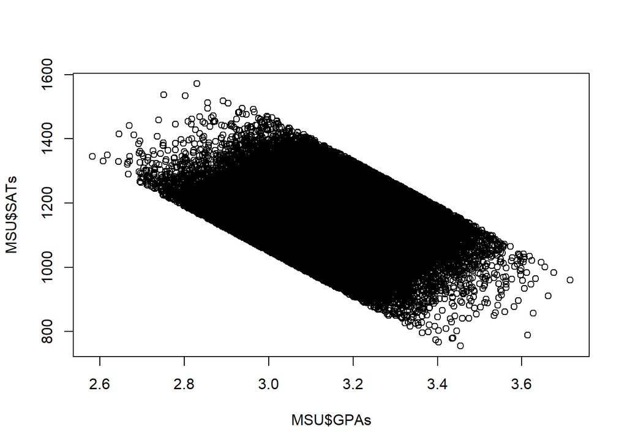

```r
plot(MSU$GPAs, MSU$SATs)
```

```r
cor(MSU$GPAs, MSU$SATs)
```

```
## [1] -0.3010839
```

*The correlation among these recent high school graduates is negative, -.301. It’s obvious when we look at how the population was subsetted.*

Can you now address the original question: Why is it that students at MSU who had high SAT scores tend to have low GPA scores?

*The phenomenon is directly related to the acceptence criteria of MSU and ESU. We are slicing the population diagonally downward, so to speak. This changes the shape of the 2d distribution and imposes a negative association on the data. But that is not in the original population.*

### Base Rate Fallacy

Suppose that we are living through a pandemic. Imagine that the hospitalization rate for those infected is 10% (if a person is infected, there’s a 10% chance that they end up in the hospital). A vaccine is developed and if a person is vaccinated then their hospitalization rate drops to 0.5%.

Early on only 5% of the population is vaccinated. What proportion of those hospitalized are vaccinated?

```r
#Your code / calculations go here
.05*.005/(.05*.005 + .95*.10)
```

```
## [1] 0.002624672
```

Later on in the pandemic 25% of the population is vaccinated. What proportion of those hospitalized are vaccinated?

```r
#Your code / calculations go here
.25*.005/(.25*.005 + .75*.10)
```

```
## [1] 0.01639344
```

Later on 90% of the population is vaccinated. What proportion of those hospitalized are vaccinated?

```r
#Your code / calculations go here
.9*.005/(.9*.005 + .1*.10)
```

```
## [1] 0.3103448
```

You hear someone on the news saying that the proportion of those vaccinated in the hospital is rising and rising, and that this is evidence that the efficacy of the vaccine is diminishing. Do you agree with this argument, or is there an other explanation?

**This is the base rate fallacy in action. The vaccination rate in the population increases. The vaccination rate among those hospitalized will naturally increase as well. If 100% of the population is vaccinated, then 100% of those hospitalized will be vaccinated. That doesn’t mean the vaccine isn’t effective, it just means the population is changing.**